# Chapter 1: Exercise 1

Colin Gillespie (Xiang Li)

## Instructions

For each line below:

1. Format the line with markdown to display what the line describes.
2. Re-render the file by pressing the `Knit HTML` button above to see if it worked.
3. Move on to the next line.

The Markdown cheatsheet is available under the `Help` button in the top menu. ***

## Exercises

### Use markdown to indicate:

A first level header

# Header

A second level header

## Header

A third level header

### Header

A fourth level header

#### Header

A fifth level header

##### Header

A sixth level header

###### Header

bold text  
**bold text** OR **bold text**

italic text *bold text* OR *bold text*

An unordered list:  
Item 1  
Item 2  
sub-item 1  
sub-item 2

- Item 1
- Item 2
  - Item 2a
  - Item 2b

An ordered list:  
Item 1  
Item 2  
sub-item 1  
sub-item 2

1. Item 1
2. Item 2
3. Item 3
   - Item 3a
   - Item 3b

A table:  
Header 1 Header 2  
Cell 1 Cell 2  
Cell 3 Cell 4

| First Header | Second Header |
| --- | --- |
| Content Cell | Content Cell |
| Content Cell | Content Cell |

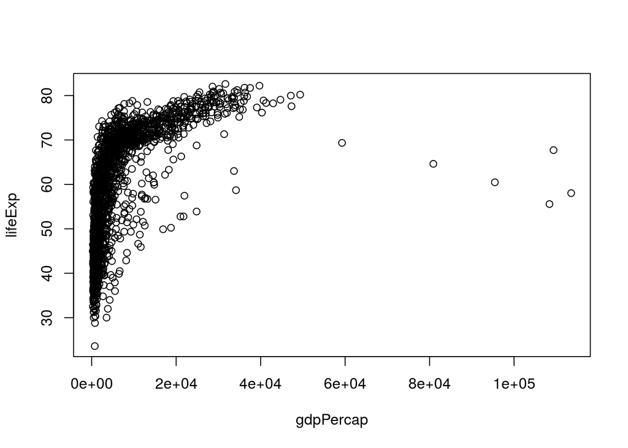

```r
library("gapminder")
data(gapminder, package = "gapminder")
plot(lifeExp~gdpPercap, data = gapminder)
```

```r
library(d3heatmap)
d3heatmap(mtcars)
```

[interactive chart not shown]

echo = true : show codes (default) echo = false : no show

eval = true : run codes (default) eval = false : don’t run codes

include = true : show outputs (default) include = false : no show

Colnames of data **mtcar** are mpg, cyl, disp, hp, drat, wt, qsec, vs, am, gear, carb